# Assignment_9

Lacee Bowen

11/8/2020

```r
df_admissions <- read.csv("../../Data/GradSchool_Admissions.csv", stringsAsFactors = FALSE)
data(df_admissions)
library(tidyverse)
library(modelr)
library(GGally)
```

##### Preface: This page is a resource for those interested in or looking to apply to a graduate school. The acceptance rate of 400 undergraduate students who have previously applied to graduate schools was recorded. Taken in to consideration was their GPA, their GRE score, and the rank of the undergraduate institution in which the student has or will be graduating from. Emphasized is school rank.

### Basic summary for admission rates:

#### (True represents those who were accepted in to graduate school and false represents those who were not accepted in to graduate school)

```r
# changes admit from 1 and 0 to true and false respectively
df_admissions$admit <- as.logical(df_admissions$admit)

# changes rank to a factor
df_admissions$rank <- as.factor(df_admissions$rank)

summary(df_admissions)
```

```
##    admit              gre             gpa        rank
##  Mode :logical   Min.   :220.0   Min.   :2.260   1: 61
##  FALSE:273       1st Qu.:520.0   1st Qu.:3.130   2:151
##  TRUE :127       Median :580.0   Median :3.395   3:121
##                  Mean   :587.7   Mean   :3.390   4: 67
##                  3rd Qu.:660.0   3rd Qu.:3.670
##                  Max.   :800.0   Max.   :4.000
```

###### 273 of the 400 applicants were denied acceptance while 127 were granted acceptance. The mean GRE score and GPA of applicants were 587.7 and 3.39 respectively. 61 applicants were from a rank 1 school, 151 were from a rank two school, 121 were from a rank 3 school, and 67 were from a rank 4 school.

### Admissions based on GPA

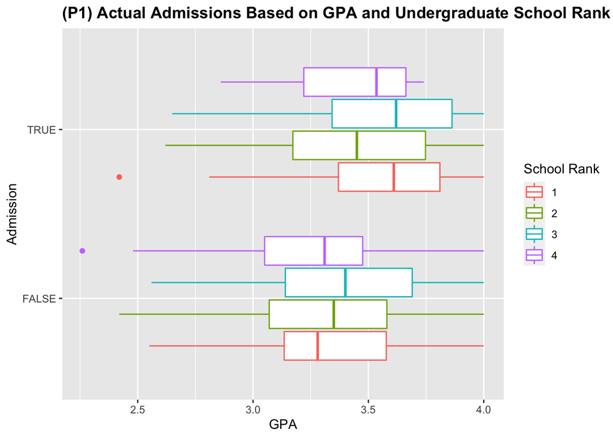

```r
p1 <- ggplot(df_admissions, aes(x = gpa, y= admit, color = rank))+
  geom_boxplot()+
  labs(title = "(P1) Actual Admissions Based on GPA and Undergraduate School Rank", x="GPA", y="Admission", legend="School Rank", color = "School Rank")+
  theme(plot.title = element_text(face = "bold"))
p1
```

P1 shows actual results of those accepted and denied admission to graduate school based on GPA and rank of undergraduate institution where true is those who were accepted and false was those who were denied. Included are values found in the summary tabel above

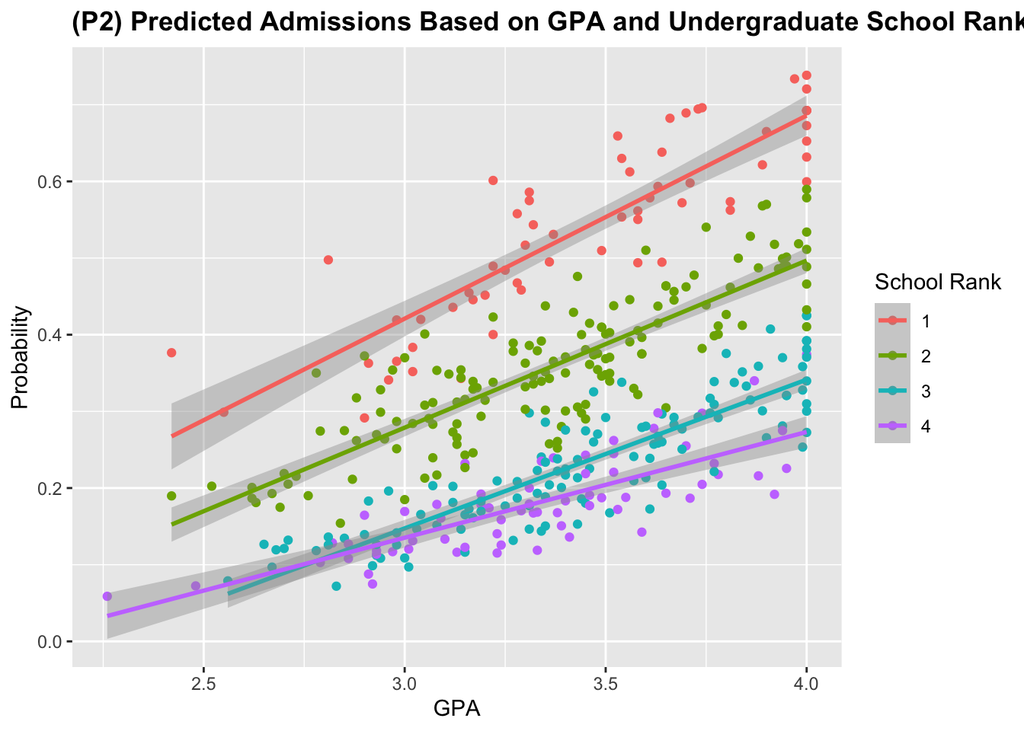

```r
df_admissions$admit <- as.logical(df_admissions$admit)
df_admissions$rank <- factor(df_admissions$rank)

mod1 <- glm(data = df_admissions, formula = admit ~ gre + gpa + rank, family = "binomial")

df_withpredictions <- add_predictions(df_admissions, mod1, type = "response")

p2 <- ggplot(df_withpredictions, aes(x = gpa, y= pred, color= rank))+
  geom_point()+
  geom_smooth(method = "lm")+
  labs(x = "GPA", y= "Probability", title = "(P2) Predicted Admissions Based on GPA and Undergraduate School Rank", color = "School Rank")+
  theme(plot.title = element_text(face = "bold"))
p2
```

### The next two graphs show prediction percentages of a student with a 3.5 GPA from a rank 1 school vs a rank 2 school given different GRE scores:

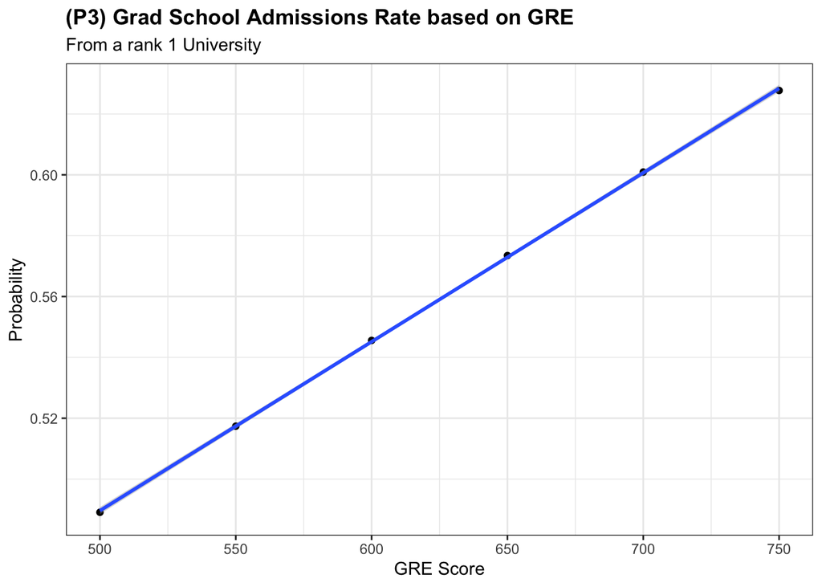

```r
hypothetical_data <- data.frame(gre=c(500, 550, 600, 650, 700, 750),
                                gpa=c(3.5, 3.5, 3.5, 3.5, 3.5, 3.5),
                                rank=c("1", "1", "1", "1", "1", "1"))

df2_withpredictions <- add_predictions(hypothetical_data, mod1, type = "response")

p3 <- ggplot(df2_withpredictions, aes(x = gre, y= pred))+
  geom_point()+
  geom_smooth(method = "lm")+
  labs(x = "GRE Score", y= "Probability", title = "(P3) Grad School Admissions Rate based on GRE", subtitle = "From a rank 1 University")+
  theme_bw()+
  theme(plot.title = element_text(face = "bold"))
p3
```

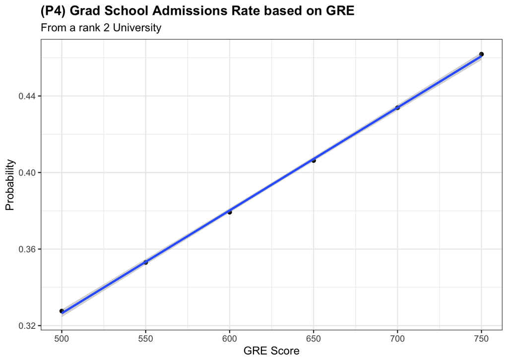

```r
hypothetical_data2 <- data.frame(gre=c(500, 550, 600, 650, 700, 750),
                                gpa=c(3.5, 3.5, 3.5, 3.5, 3.5, 3.5),
                                rank=c("2", "2", "2", "2", "2", "2"))

df3_withpredictions <- add_predictions(hypothetical_data2, mod1, type = "response")

p4 <- ggplot(df3_withpredictions, aes(x = gre, y= pred))+
  geom_point()+
  geom_smooth(method = "lm")+
  labs(x = "GRE Score", y= "Probability", title = "(P4) Grad School Admissions Rate based on GRE", subtitle = "From a rank 2 University")+
  theme_bw()+
  theme(plot.title = element_text(face = "bold"))
p4
```

P3 and P4 show that two students with the same GPA and GRE score have significantly different chances of being accepted to graduate school solely base on the rank of undergraduate institution they graduate from.

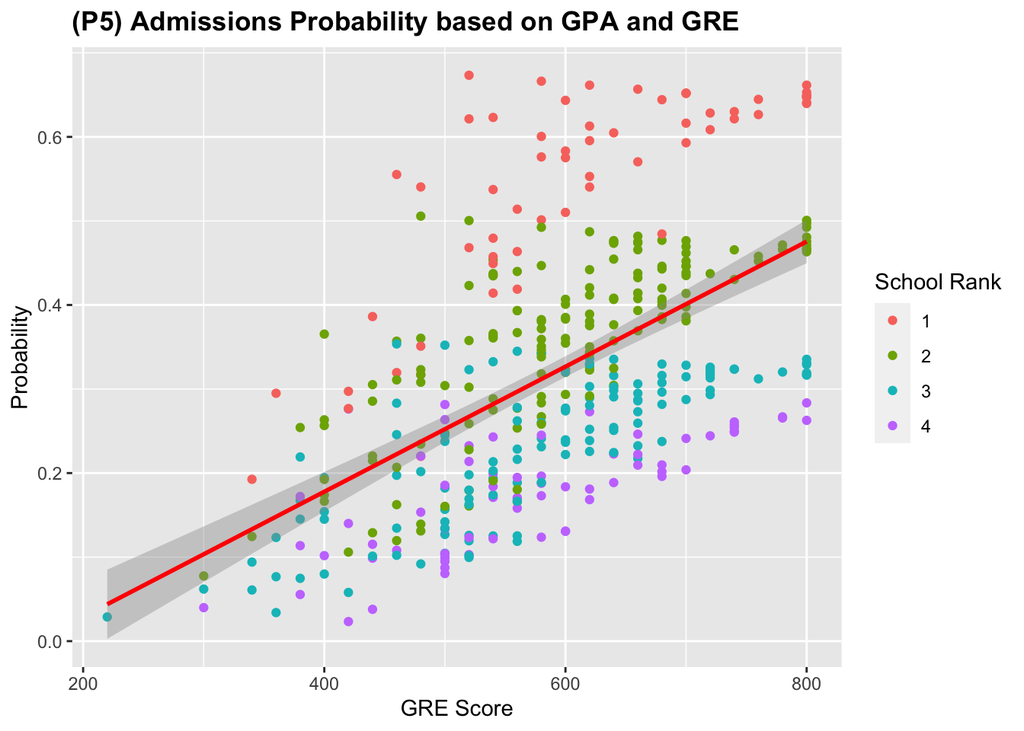

```r
mod3 <- glm(data = df_admissions, formula = admit ~ gre * gpa + rank, family = "binomial")

hypothetical_data3 <- data.frame(gre=c(500, 550, 600, 650, 700, 750),
                                gpa=c(3.5, 3.5, 3.5, 3.5, 3.5, 3.5),
                                rank=c("2", "2", "2", "2", "2", "2"))

df4_withpredictions <- add_predictions(df_admissions, mod3, type = "response")

p5 <- ggplot(df4_withpredictions, aes(x = gre, y= pred, color = rank))+
  geom_point()+
  geom_smooth(method = "lm", color = "red")+
  labs(title = "(P5) Admissions Probability based on GPA and GRE", x= "GRE Score", y= "Probability", color = "School Rank")+
  theme(plot.title = element_text(face = "bold"))
p5
```

### P6 takes in to consideration the rank of undergraduate institutions

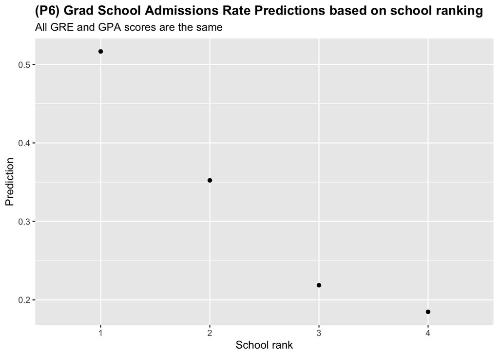

```r
hypothetical_data4 <- data.frame(gre=c(587.7, 587.7, 587.7, 587.7),
                                gpa=c(3.390, 3.390, 3.390, 3.390),
                                rank=c("1", "2", "3", "4"))

df6_withpredictions <- add_predictions(hypothetical_data4, mod1, type = "response")

p6 <- ggplot(df6_withpredictions, aes(x = rank, y= pred))+
  geom_point()+
  labs(x = "School rank", y= "Prediction", title = "(P6) Grad School Admissions Rate Predictions based on school ranking", subtitle = "All GRE and GPA scores are the same")+
  theme(plot.title = element_text(face = "bold"))
p6
```

This plot shows the probability of 4 students getting accepted in to graduate school who have the exact average GPA (3.390) and GRE (587.7) score as seen in the summary above but come from differently ranked undergraduate institutions